# peruocc: Recuperación y Consolidación de Ocurrencias de Biodiversidad en Unidades Administrativas del Perú

[figure not shown]

`peruocc` es un paquete y conjunto de herramientas en R diseñado para buscar, descargar, filtrar, validar y consolidar registros de ocurrencias de biodiversidad (**flora y fauna**) en el territorio peruano, utilizando como marco espacial las delimitaciones administrativas oficiales a escala de **distritos** y **provincias**.

El paquete integra y estandariza la información disponible de dos de los mayores repositorios globales de biodiversidad: **GBIF** (*Global Biodiversity Information Facility*) e **iNaturalist**, generando un objeto unificado con atributos estandarizados y trazabilidad completa dentro del área de interés.

## Características Principales

1. **Marco Administrativo Oficial (Distritos y Provincias)**:
   - Recupera dinámicamente geometrías oficiales provistas por el INEI a través del paquete **`geoperu`**.
   - Admite consultas a nivel de **distrito** y consolidación disuelta a nivel de **provincia**.
2. **Caché Local Inteligente (`.rds`)**:
   - Almacena en disco los límites departamentales descargados, reduciendo drásticamente los tiempos de respuesta en consultas recurrentes.
3. **Flujo Espacial y Topológico Riguroso**:
   - Corrige automáticamente la orientación geométrica a sentido antihorario (**CCW**) según los estándares OGC/GBIF.
   - Aplica simplificación métrica adaptativa en proyecciones UTM para polígonos complejos en consultas de API.
   - Realiza una **intersección espacial exacta (`sf::st_intersects`)** en R con el polígono detallado original, garantizando que sólo se conserven los registros estrictamente dentro de los límites administrativos.
4. **Consolidación y Estandarización de Datos**:
   - Homogeneiza atributos de GBIF e iNaturalist hacia un esquema estándar alineado con **Darwin Core**.
   - Retorna una estructura consolidada que contiene el polígono espacial (`sf`), el conjunto de ocurrencias tabulares (`data.frame`), el resumen analítico y los parámetros de ejecución.
5. **Exportación y Trazabilidad**:
   - Exporta automáticamente a formatos **CSV**, capas espaciales **GeoJSON**, mapas de alta resolución (**PNG**) y manifiestos de reproducibilidad (**JSON**).

## Flujo de Integración de Datos

```
               ┌──────────────────────────────┐
               │    Unidad Administrativa     │
               │   (Distrito o Provincia)     │
               └──────────────┬───────────────┘
                              │
               ┌──────────────▼──────────────┐
               │  Geometría Oficial geoperu   │
               │   + Validación / Caché RDS   │
               └──────────────┬───────────────┘
                              │
             ┌────────────────┴────────────────┐
             │                                 │
  ┌──────────▼──────────┐           ┌──────────▼──────────┐
  │  Consulta a GBIF    │           │ Consulta iNaturalist│
  │  (WKT / Taxonomía)  │           │   (Bounding Box)    │
  └──────────┬──────────┘           └──────────┬──────────┘
             │                                 │
             └────────────────┬────────────────┘
                              │
               ┌──────────────▼──────────────┐
               │ Filtrado Espacial en R       │
               │ (sf::st_intersects exacto)  │
               └──────────────┬───────────────┘
                              │
               ┌──────────────▼──────────────┐
               │ Estandarización Darwin Core │
               │   + Deduplicación interna   │
               └──────────────┬───────────────┘
                              │
               ┌──────────────▼──────────────┐
               │ Objeto Consolidado Final     │
               │ (sf + data.frame + Resumen) │
               └─────────────────────────────┘
```

1. **Obtención y Preparación del Polígono**: Se consulta `geoperu` para descargar o cargar desde el caché local el departamento correspondiente. Si la consulta es distrital, se extrae el distrito específico; si es provincial, se disuelven espacialmente todos sus distritos componentes (`sf::st_union`).
2. **Consulta a Repositorios Vivos**:
   - **GBIF**: Se envía el polígono en formato WKT (simplificado si supera límites de caracteres) junto con los filtros taxonómicos (Reino, taxón específico o grupo).
   - **iNaturalist**: Se utiliza la caja delimitadora (*Bounding Box*) del polígono junto a los criterios de búsqueda (flora/fauna, taxón o texto libre).
3. **Validación Espacial en Memoria**: Ambos conjuntos de puntos recuperados se transforman a objetos espaciales `sf` (EPSG:4326) y se intersecan topológicamente con el polígono detallado original, eliminando cualquier falso positivo fuera del perímetro.
4. **Estandarización**: Se mapean los campos nativos de ambas fuentes a una estructura de columnas común, preservando identificadores de origen, coordenadas, taxonomía, fecha y jerarquía administrativa.

## Instalación y Carga

### 1. Desde GitHub:

```r
# Instalar paquete directamente desde el repositorio en GitHub
# install.packages("remotes")
remotes::install_github("PaulESantos/peruocc")
```

### 2. Configuración de directorio de trabajo:

```r
library(peruocc)

# Configurar directorio donde se guardarán caché, resultados y manifiestos
peruocc_data_dir("peruocc-output")
```

## Guía de Uso y Escalabilidad Funcional

El paquete proporciona interfaces tanto específicas como unificadas para consultar ocurrencias en diferentes niveles administrativos:

### 1. Consulta Unificada (`buscar_especies_peru`)

Permite seleccionar el nivel administrativo mediante el argumento `nivel = c("distrito", "provincia")`:

```r
# Consulta general a nivel distrital en memoria
res_distrito <- buscar_especies_peru(
  nombre = "Miraflores",
  nivel = "distrito",
  departamento = "Lima",
  provincia = "Lima",
  grupo = "flora",            # "flora", "fauna" o NULL
  limite_por_api = 200
)
```

```
#> =====================================================================
#> BUSQUEDA INTEGRADA EN DISTRITO: MIRAFLORES
#>   Provincia: Lima
#>   Departamento: Lima
#> =====================================================================
#>
#> [SPATIAL] Cargando limites de LIMA desde el cache local...
#> [GBIF] Iniciando busqueda de ocurrencias...
#> [SPATIAL] Poligono simplificado con exito a tolerancia de 100 metros (WKT: 822 caracteres).
#> [GBIF] Filtrando por reino Plantae (Flora).
#> [GBIF] Consultando registros dentro del poligono de 'MIRAFLORES' (limite: 200)...
#> [GBIF] Busqueda finalizada. Se filtraron 198 registros que caen dentro del poligono seleccionado.
#> [iNaturalist] Iniciando busqueda de ocurrencias...
#> [iNaturalist] Filtrando por reino Plantae (Flora).
#> [iNaturalist] Consultando registros dentro de la caja delimitadora de 'MIRAFLORES' (limite: 200)...
#> [iNaturalist] Se descargaron 200 registros en la caja delimitadora. Aplicando filtro espacial...
#> [iNaturalist] Busqueda finalizada. 167 de 200 registros caen dentro del poligono seleccionado.
#>
#> [RESULTADO] Consolidacion exitosa. Total de registros unificados: 365
#>        Origen Registros
#> 1        GBIF       198
#> 2 iNaturalist       167
#> 3       Total       365
#>
#> [ARCHIVO] Resultados guardados en: 'D:/peruocc/peruocc-output/processed/ocurrencias_20260819T042527Z_p25272_distrito_miraflores_flora.csv'
#> [ARCHIVO] Capa espacial guardada en GeoJSON: 'D:/peruocc/peruocc-output/processed/ocurrencias_20260819T042527Z_p25272_distrito_miraflores_flora.geojson'
#> [ARCHIVO] Manifiesto de reproducibilidad guardado en: 'D:/peruocc/peruocc-output/processed/manifiesto_20260819T042527Z_p25272_distrito_miraflores_flora.json'
```

```r
res_distrito$ocurrencias |>
  dplyr::as_tibble()
```

```
#> # A tibble: 365 × 24
#>    occurrenceID sourceRecordID sourceURL        datasetKey license basisOfRecord
#>    <chr>        <chr>          <chr>            <chr>      <chr>   <chr>
#>  1 6129981207   6129981207     https://www.gbi… 50c9509d-… http:/… HUMAN_OBSERV…
#>  2 6179051389   6179051389     https://www.gbi… 50c9509d-… http:/… HUMAN_OBSERV…
#>  3 6147543635   6147543635     https://www.gbi… 50c9509d-… http:/… HUMAN_OBSERV…
#>  4 6147566368   6147566368     https://www.gbi… 50c9509d-… http:/… HUMAN_OBSERV…
#>  5 6147649969   6147649969     https://www.gbi… 50c9509d-… http:/… HUMAN_OBSERV…
#>  6 6159649674   6159649674     https://www.gbi… 50c9509d-… http:/… HUMAN_OBSERV…
#>  7 6171247345   6171247345     https://www.gbi… 50c9509d-… http:/… HUMAN_OBSERV…
#>  8 6179365614   6179365614     https://www.gbi… 50c9509d-… http:/… HUMAN_OBSERV…
#>  9 6431906476   6431906476     https://www.gbi… 50c9509d-… http:/… HUMAN_OBSERV…
#> 10 6178459982   6178459982     https://www.gbi… 50c9509d-… http:/… HUMAN_OBSERV…
#> # ℹ 355 more rows
#> # ℹ 18 more variables: scientificName <chr>, decimalLatitude <dbl>,
#> #   decimalLongitude <dbl>, eventDate <chr>, taxonRank <chr>, kingdom <chr>,
#> #   phylum <chr>, class <chr>, order <chr>, family <chr>, genus <chr>,
#> #   species <chr>, recordedBy <chr>, coordinateUncertaintyInMeters <dbl>,
#> #   source <chr>, district <chr>, province <chr>, department <chr>
```

```r
# Consulta general a nivel provincial en memoria
res_provincia <- buscar_especies_peru(
  nombre = "Cusco",
  nivel = "provincia",
  departamento = "Cusco",
  grupo = "fauna",
  limite_por_api = 200
)
```

```
#> =====================================================================
#> BUSQUEDA INTEGRADA EN PROVINCIA: CUSCO
#>   Departamento: Cusco
#> =====================================================================
#>
#> [SPATIAL] Cargando limites de CUSCO desde el cache local...
#> [GBIF] Iniciando busqueda de ocurrencias...
#> [SPATIAL] Poligono simplificado con exito a tolerancia de 300 metros (WKT: 1215 caracteres).
#> [GBIF] Filtrando por reino Animalia (Fauna).
#> [GBIF] Consultando registros dentro del poligono de 'CUSCO' (limite: 200)...
#> [GBIF] Busqueda finalizada. Se filtraron 200 registros que caen dentro del poligono seleccionado.
#> [iNaturalist] Iniciando busqueda de ocurrencias...
#> [iNaturalist] Filtrando por reino Animalia (Fauna).
#> [iNaturalist] Consultando registros dentro de la caja delimitadora de 'CUSCO' (limite: 200)...
#> [iNaturalist] Se descargaron 200 registros en la caja delimitadora. Aplicando filtro espacial...
#> [iNaturalist] Busqueda finalizada. 181 de 200 registros caen dentro del poligono seleccionado.
#>
#> [RESULTADO] Consolidacion exitosa. Total de registros unificados: 381
#>        Origen Registros
#> 1        GBIF       200
#> 2 iNaturalist       181
#> 3       Total       381
#>
#> [ARCHIVO] Resultados guardados en: 'D:/peruocc/peruocc-output/processed/ocurrencias_20260819T042537Z_p25272_provincia_cusco_fauna.csv'
#> [ARCHIVO] Capa espacial guardada en GeoJSON: 'D:/peruocc/peruocc-output/processed/ocurrencias_20260819T042537Z_p25272_provincia_cusco_fauna.geojson'
#> [ARCHIVO] Manifiesto de reproducibilidad guardado en: 'D:/peruocc/peruocc-output/processed/manifiesto_20260819T042537Z_p25272_provincia_cusco_fauna.json'
```

```r
res_provincia$ocurrencias |>
  dplyr::as_tibble()
```

```
#> # A tibble: 381 × 24
#>    occurrenceID sourceRecordID sourceURL        datasetKey license basisOfRecord
#>    <chr>        <chr>          <chr>            <chr>      <chr>   <chr>
#>  1 5938271716   5938271716     https://www.gbi… 50c9509d-… http:/… HUMAN_OBSERV…
#>  2 5938631678   5938631678     https://www.gbi… 50c9509d-… http:/… HUMAN_OBSERV…
#>  3 6129873325   6129873325     https://www.gbi… 50c9509d-… http:/… HUMAN_OBSERV…
#>  4 6130064972   6130064972     https://www.gbi… 50c9509d-… http:/… HUMAN_OBSERV…
#>  5 6130410898   6130410898     https://www.gbi… 50c9509d-… http:/… HUMAN_OBSERV…
#>  6 6130438735   6130438735     https://www.gbi… 50c9509d-… http:/… HUMAN_OBSERV…
#>  7 6130955903   6130955903     https://www.gbi… 50c9509d-… http:/… HUMAN_OBSERV…
#>  8 6130998009   6130998009     https://www.gbi… 50c9509d-… http:/… HUMAN_OBSERV…
#>  9 6131276759   6131276759     https://www.gbi… 50c9509d-… http:/… HUMAN_OBSERV…
#> 10 6131426727   6131426727     https://www.gbi… 50c9509d-… http:/… HUMAN_OBSERV…
#> # ℹ 371 more rows
#> # ℹ 18 more variables: scientificName <chr>, decimalLatitude <dbl>,
#> #   decimalLongitude <dbl>, eventDate <chr>, taxonRank <chr>, kingdom <chr>,
#> #   phylum <chr>, class <chr>, order <chr>, family <chr>, genus <chr>,
#> #   species <chr>, recordedBy <chr>, coordinateUncertaintyInMeters <dbl>,
#> #   source <chr>, district <chr>, province <chr>, department <chr>
```

### 2. Consultas Específicas por Nivel

#### A. A nivel de Distrito (`buscar_especies_distrito`)

```r
resultado_dist <- buscar_especies_distrito(
  distrito = "Tambopata",
  departamento = "Madre de Dios",
  provincia = "Tambopata",
  nombre_cientifico = "Panthera onca", # Opcional: filtro por especie
  limite_por_api = 100,
  guardar_resultados = FALSE
)
```

```
#> =====================================================================
#> BUSQUEDA INTEGRADA EN DISTRITO: TAMBOPATA
#>   Provincia: Tambopata
#>   Departamento: Madre de Dios
#> =====================================================================
#>
#> [SPATIAL] Cargando limites de MADRE DE DIOS desde el cache local...
#> [GBIF] Iniciando busqueda de ocurrencias...
#> [SPATIAL] Poligono simplificado con exito a tolerancia de 8100 metros (WKT: 379 caracteres).
#> [GBIF] Resolviendo taxonomia para 'Panthera onca'...
#> [GBIF] Taxon resuelto: Panthera onca (Linnaeus, 1758) (Key: 5219426, Rank: SPECIES)
#> [GBIF] Consultando registros dentro del poligono de 'TAMBOPATA' (limite: 100)...
#> [GBIF] Busqueda finalizada. Se filtraron 21 registros que caen dentro del poligono seleccionado.
#> [iNaturalist] Iniciando busqueda de ocurrencias...
#> [iNaturalist] Consultando registros dentro de la caja delimitadora de 'TAMBOPATA' (limite: 100)...
#> [iNaturalist] Se descargaron 100 registros en la caja delimitadora. Aplicando filtro espacial...
#> [iNaturalist] Busqueda finalizada. 15 de 100 registros caen dentro del poligono seleccionado.
#>
#> [RESULTADO] Consolidacion exitosa. Total de registros unificados: 36
#>        Origen Registros
#> 1        GBIF        21
#> 2 iNaturalist        15
#> 3       Total        36
```

```r
resultado_dist$ocurrencias |>
  dplyr::as_tibble()
```

```
#> # A tibble: 36 × 24
#>    occurrenceID sourceRecordID sourceURL        datasetKey license basisOfRecord
#>    <chr>        <chr>          <chr>            <chr>      <chr>   <chr>
#>  1 6334829706   6334829706     https://www.gbi… 50c9509d-… http:/… HUMAN_OBSERV…
#>  2 4597092810   4597092810     https://www.gbi… 50c9509d-… http:/… HUMAN_OBSERV…
#>  3 4606894492   4606894492     https://www.gbi… 50c9509d-… http:/… HUMAN_OBSERV…
#>  4 4022300813   4022300813     https://www.gbi… 50c9509d-… http:/… HUMAN_OBSERV…
#>  5 4852820765   4852820765     https://www.gbi… 50c9509d-… http:/… HUMAN_OBSERV…
#>  6 1990572488   1990572488     https://www.gbi… 50c9509d-… http:/… HUMAN_OBSERV…
#>  7 1571080404   1571080404     https://www.gbi… 50c9509d-… http:/… HUMAN_OBSERV…
#>  8 1571080408   1571080408     https://www.gbi… 50c9509d-… http:/… HUMAN_OBSERV…
#>  9 6236055510   6236055510     https://www.gbi… 50c9509d-… http:/… HUMAN_OBSERV…
#> 10 3499457688   3499457688     https://www.gbi… 50c9509d-… http:/… HUMAN_OBSERV…
#> # ℹ 26 more rows
#> # ℹ 18 more variables: scientificName <chr>, decimalLatitude <dbl>,
#> #   decimalLongitude <dbl>, eventDate <chr>, taxonRank <chr>, kingdom <chr>,
#> #   phylum <chr>, class <chr>, order <chr>, family <chr>, genus <chr>,
#> #   species <chr>, recordedBy <chr>, coordinateUncertaintyInMeters <dbl>,
#> #   source <chr>, district <chr>, province <chr>, department <chr>
```

#### B. A nivel de Provincia (`buscar_especies_provincia`)

```r
resultado_prov <- buscar_especies_provincia(
  provincia = "Urubamba",
  departamento = "Cusco",
  grupo = "flora",
  limite_por_api = 300,
  guardar_resultados = FALSE
)
```

```
#> =====================================================================
#> BUSQUEDA INTEGRADA EN PROVINCIA: URUBAMBA
#>   Departamento: Cusco
#> =====================================================================
#>
#> [SPATIAL] Cargando limites de CUSCO desde el cache local...
#> [GBIF] Iniciando busqueda de ocurrencias...
#> [SPATIAL] Poligono simplificado con exito a tolerancia de 900 metros (WKT: 904 caracteres).
#> [GBIF] Filtrando por reino Plantae (Flora).
#> [GBIF] Consultando registros dentro del poligono de 'URUBAMBA' (limite: 300)...
#> [GBIF] Busqueda finalizada. Se filtraron 299 registros que caen dentro del poligono seleccionado.
#> [iNaturalist] Iniciando busqueda de ocurrencias...
#> [iNaturalist] Filtrando por reino Plantae (Flora).
#> [iNaturalist] Consultando registros dentro de la caja delimitadora de 'URUBAMBA' (limite: 300)...
#> [iNaturalist] Se descargaron 300 registros en la caja delimitadora. Aplicando filtro espacial...
#> [iNaturalist] Busqueda finalizada. 276 de 300 registros caen dentro del poligono seleccionado.
#>
#> [RESULTADO] Consolidacion exitosa. Total de registros unificados: 575
#>        Origen Registros
#> 1        GBIF       299
#> 2 iNaturalist       276
#> 3       Total       575
```

```r
resultado_prov$ocurrencias |>
  dplyr::as_tibble()
```

```
#> # A tibble: 575 × 24
#>    occurrenceID sourceRecordID sourceURL        datasetKey license basisOfRecord
#>    <chr>        <chr>          <chr>            <chr>      <chr>   <chr>
#>  1 5938503101   5938503101     https://www.gbi… 50c9509d-… http:/… HUMAN_OBSERV…
#>  2 6129882199   6129882199     https://www.gbi… 50c9509d-… http:/… HUMAN_OBSERV…
#>  3 6129928896   6129928896     https://www.gbi… 50c9509d-… http:/… HUMAN_OBSERV…
#>  4 6129994865   6129994865     https://www.gbi… 50c9509d-… http:/… HUMAN_OBSERV…
#>  5 6130002986   6130002986     https://www.gbi… 50c9509d-… http:/… HUMAN_OBSERV…
#>  6 6130015299   6130015299     https://www.gbi… 50c9509d-… http:/… HUMAN_OBSERV…
#>  7 6130027226   6130027226     https://www.gbi… 50c9509d-… http:/… HUMAN_OBSERV…
#>  8 6130067924   6130067924     https://www.gbi… 50c9509d-… http:/… HUMAN_OBSERV…
#>  9 6130290679   6130290679     https://www.gbi… 50c9509d-… http:/… HUMAN_OBSERV…
#> 10 6130302854   6130302854     https://www.gbi… 50c9509d-… http:/… HUMAN_OBSERV…
#> # ℹ 565 more rows
#> # ℹ 18 more variables: scientificName <chr>, decimalLatitude <dbl>,
#> #   decimalLongitude <dbl>, eventDate <chr>, taxonRank <chr>, kingdom <chr>,
#> #   phylum <chr>, class <chr>, order <chr>, family <chr>, genus <chr>,
#> #   species <chr>, recordedBy <chr>, coordinateUncertaintyInMeters <dbl>,
#> #   source <chr>, district <chr>, province <chr>, department <chr>
```

### 3. Visualización Cartográfica (`graficar_ocurrencias`)

Genera mapas temáticos con `ggplot2` coloreando según la base de datos de origen (`source`) o reino taxonómico (`kingdom`):

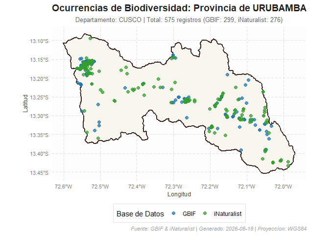

```r
# Mapa clasificado por fuente de datos (GBIF vs iNaturalist)
mapa_fuente <- graficar_ocurrencias(resultado_prov,
                                    color_por = "source",
                                    guardar_mapa = FALSE)

mapa_fuente
```

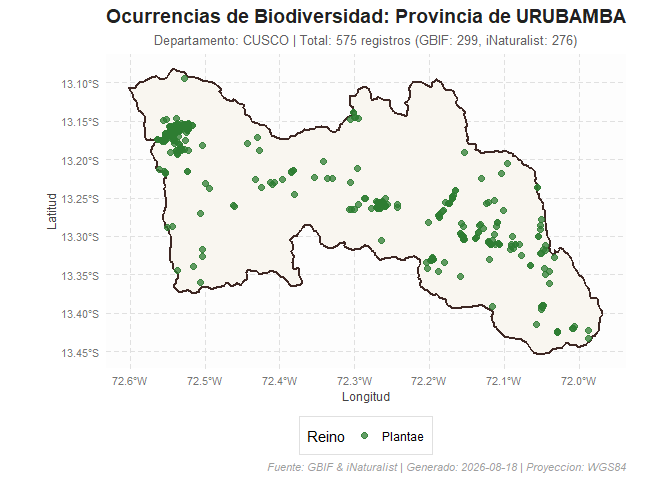

```r
# Mapa clasificado por Reino (Plantae vs Animalia)
mapa_reino <- graficar_ocurrencias(resultado_prov,
                                   color_por = "kingdom",
                                   guardar_mapa = FALSE)
mapa_reino
```

### 4. Exportación de Resultados a Disco (`exportar_resultados`)

Guarda los registros consolidados en formatos CSV, capas vectoriales GeoJSON y manifiestos JSON de reproducibilidad:

```r
# Exportar todos los formatos
exportar_resultados(resultado_prov)

# O exportar selectivamente a una carpeta personalizada
exportar_resultados(
  resultado = resultado_prov,
  dir_salida = "mis_datos_biodiversidad",
  formatos = c("csv", "geojson")
)
```

## Estructura del Objeto Consolidado

Las funciones de búsqueda devuelven una lista estructurada con los siguientes elementos:

1. **`unidad_sf`**: Objeto espacial `sf` con la geometría oficial y válida del distrito o provincia consultada.
2. **`ocurrencias`**: Dataframe estandarizado con los registros consolidados y deduplicados.
3. **`resumen`**: Lista con estadísticas de cobertura, registros por fuente, conteos totales y metadatos de las APIs.
4. **`parametros`**: Registro de los argumentos utilizados para la consulta.

### Columnas del Dataframe Estandarizado

| Columna | Tipo | Descripción |
| --- | --- | --- |
| `occurrenceID` | `character` | Identificador único del registro / URI oficial. |
| `sourceRecordID` | `character` | Identificador nativo en la base de datos de origen. |
| `sourceURL` | `character` | Enlace directo al registro en el repositorio web. |
| `source` | `character` | Proveedor del dato (`GBIF` o `iNaturalist`). |
| `scientificName` | `character` | Nombre científico completo del taxón. |
| `decimalLatitude` | `numeric` | Latitud en coordenadas geográficas (WGS84). |
| `decimalLongitude` | `numeric` | Longitud en coordenadas geográficas (WGS84). |
| `coordinateUncertaintyInMeters` | `numeric` | Incertidumbre posicional de las coordenadas (en metros). |
| `eventDate` | `character` | Fecha del registro u observación. |
| `taxonRank` | `character` | Rango taxonómico asignado (especie, género, etc.). |
| `kingdom` | `character` | Reino biológico (Plantae, Animalia, etc.). |
| `phylum`, `class`, `order`, `family`, `genus`, `species` | `character` | Jerarquía taxonómica (disponible según la fuente). |
| `recordedBy` | `character` | Observador, colector o usuario que registró la ocurrencia. |
| `license`, `basisOfRecord` | `character` | Licencia de uso y base del registro. |
| `district` | `character` | Nombre del distrito correspondiente. |
| `province` | `character` | Nombre de la provincia correspondiente. |
| `department` | `character` | Nombre del departamento correspondiente. |

## Trazabilidad y Reproducibilidad

Cada ejecución exporta artefactos con identificadores únicos basados en timestamp UTC (`YYYYMMDDTHHMMSSZ`):

- **`processed/ocurrencias_*.csv`**: Tabla consolidada en formato CSV.
- **`processed/ocurrencias_*.geojson`**: Capa vectorial para visualización en QGIS, ArcGIS u otras plataformas SIG.
- **`processed/manifiesto_*.json`**: Manifiesto con la versión de R, versiones de paquetes (`sf`, `rgbif`, `rinat`, etc.), polígono WKT, CRS, parámetros y metadatos de la corrida.
- **`results/mapa_*.png`**: Mapa estático generado a 300 DPI.